# How to Make Custom Coefficient Plots

Kaitlin Swinnerton

8/30/2021

This file will walk you through how to make a custom coefficient plot. It will utilize nested dataframes to fit many models efficiently, and broom::tidy to convert model output into tidy dataframes. These techniques aren’t the focus on the presentation, but they are great tools to use and I would recommend trying them!

Import libraries

```r
# load libraries
if (!require("pacman")){
  install.packages("pacman", repos='http://cran.us.r-project.org')
}
library(pacman)
p_load(
  # tidyverse packages
  "plyr", "tidyverse", "broom", "glue","modelr",
  # data set
  "gapminder"
  )
```

# Step 1: Fit models

I’ll be following steps from the “Many Models” example in [R for Data Science](https://r4ds.had.co.nz/many-models.html) to fit many models on the `gapminder` dataset. I will then show how to take the results from those models and display the coeffiecients in a custom coefficient plot.

First, we’ll take a look at the data

```r
gapminder
```

```
## # A tibble: 1,704 x 6
##    country     continent  year lifeExp      pop gdpPercap
##    <fct>       <fct>     <int>   <dbl>    <int>     <dbl>
##  1 Afghanistan Asia       1952    28.8  8425333      779.
##  2 Afghanistan Asia       1957    30.3  9240934      821.
##  3 Afghanistan Asia       1962    32.0 10267083      853.
##  4 Afghanistan Asia       1967    34.0 11537966      836.
##  5 Afghanistan Asia       1972    36.1 13079460      740.
##  6 Afghanistan Asia       1977    38.4 14880372      786.
##  7 Afghanistan Asia       1982    39.9 12881816      978.
##  8 Afghanistan Asia       1987    40.8 13867957      852.
##  9 Afghanistan Asia       1992    41.7 16317921      649.
## 10 Afghanistan Asia       1997    41.8 22227415      635.
## # … with 1,694 more rows
```

We’re going to investigate how life expectancy (`lifeExp`) changes over time (`year`) for each country (`country`).

We’ll begin by creating a nested dataframe grouped by `country` and `continent`. This will make it easier to fit many models at once.

```r
by_country <- gapminder %>%
  group_by(country, continent) %>%
  nest()

by_country
```

```
## # A tibble: 142 x 3
## # Groups:   country, continent [142]
##    country     continent data
##    <fct>       <fct>     <list>
##  1 Afghanistan Asia      <tibble [12 × 4]>
##  2 Albania     Europe    <tibble [12 × 4]>
##  3 Algeria     Africa    <tibble [12 × 4]>
##  4 Angola      Africa    <tibble [12 × 4]>
##  5 Argentina   Americas  <tibble [12 × 4]>
##  6 Australia   Oceania   <tibble [12 × 4]>
##  7 Austria     Europe    <tibble [12 × 4]>
##  8 Bahrain     Asia      <tibble [12 × 4]>
##  9 Bangladesh  Asia      <tibble [12 × 4]>
## 10 Belgium     Europe    <tibble [12 × 4]>
## # … with 132 more rows
```

Next, we’ll define a model-fitting function and apply it to every dataframe within `by_country`

```r
# function that regresses year on life expectancy
country_model <- function(df) {
  lm(lifeExp ~ year, data = df)
}

# create a new column in the nested dataframe with the fitted models
by_country <- by_country %>%
  mutate(model = map(data, country_model))

by_country
```

```
## # A tibble: 142 x 4
## # Groups:   country, continent [142]
##    country     continent data              model
##    <fct>       <fct>     <list>            <list>
##  1 Afghanistan Asia      <tibble [12 × 4]> <lm>
##  2 Albania     Europe    <tibble [12 × 4]> <lm>
##  3 Algeria     Africa    <tibble [12 × 4]> <lm>
##  4 Angola      Africa    <tibble [12 × 4]> <lm>
##  5 Argentina   Americas  <tibble [12 × 4]> <lm>
##  6 Australia   Oceania   <tibble [12 × 4]> <lm>
##  7 Austria     Europe    <tibble [12 × 4]> <lm>
##  8 Bahrain     Asia      <tibble [12 × 4]> <lm>
##  9 Bangladesh  Asia      <tibble [12 × 4]> <lm>
## 10 Belgium     Europe    <tibble [12 × 4]> <lm>
## # … with 132 more rows
```

Convert fitted model objects into tidy data frames with confidence intervals. We will end up with a dataframe with estimates, standard errors, test statistics, p values, and confidence intervals for each term for each model.

```r
mods <- by_country %>%
  mutate(tidy_model = map(model, ~tidy(.x, conf.int = TRUE))) %>%
  unnest(tidy_model)

mods
```

```
## # A tibble: 284 x 11
## # Groups:   country, continent [142]
##    country  continent data    model term   estimate std.error statistic  p.value
##    <fct>    <fct>     <list>  <lis> <chr>     <dbl>     <dbl>     <dbl>    <dbl>
##  1 Afghani… Asia      <tibbl… <lm>  (Inte… -5.08e+2  40.5        -12.5  1.93e- 7
##  2 Afghani… Asia      <tibbl… <lm>  year    2.75e-1   0.0205      13.5  9.84e- 8
##  3 Albania  Europe    <tibbl… <lm>  (Inte… -5.94e+2  65.7         -9.05 3.94e- 6
##  4 Albania  Europe    <tibbl… <lm>  year    3.35e-1   0.0332      10.1  1.46e- 6
##  5 Algeria  Africa    <tibbl… <lm>  (Inte… -1.07e+3  43.8        -24.4  3.07e-10
##  6 Algeria  Africa    <tibbl… <lm>  year    5.69e-1   0.0221      25.7  1.81e-10
##  7 Angola   Africa    <tibbl… <lm>  (Inte… -3.77e+2  46.6         -8.08 1.08e- 5
##  8 Angola   Africa    <tibbl… <lm>  year    2.09e-1   0.0235       8.90 4.59e- 6
##  9 Argenti… Americas  <tibbl… <lm>  (Inte… -3.90e+2   9.68       -40.3  2.14e-12
## 10 Argenti… Americas  <tibbl… <lm>  year    2.32e-1   0.00489     47.4  4.22e-13
## # … with 274 more rows, and 2 more variables: conf.low <dbl>, conf.high <dbl>
```

# Plot results

Now, we can use this dataframe to make our coefficient plots. We will be comparing the beta coeffiecient for `year` by country by continent.

First, we’ll look at countries in the Americas.

To make the plot, we will first filter the dataframe to include only the continent and term of interest. Then we will construct the plot itself. Our coefficient plot will show the point estimates with 95% confidence intervals on the x-axis and the country names on the y-axis. To construct this using ggplot, we will need to included the following geom:  
* `geom_point` for the point estimate  
* `geom_errorbarh` for the confidence intervals  
* `geom_vline` for the reference line (0)

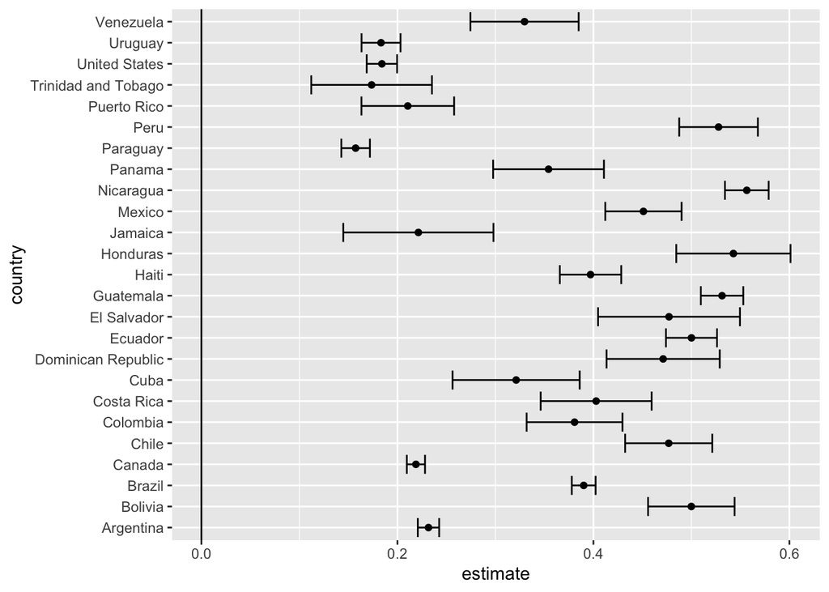

```r
# filter dataframe
mods %>%
  filter(
    continent == "Americas",
    term == "year"
    ) %>%
  # several elements of the plot will be used by multiple geoms
  # set those within the ggplot() call at the top to pass to each geom
  ggplot(aes(x = estimate, y = country)) +
  # plot the point estimate
  geom_point() +
  # plot the confidence intervals
  geom_errorbarh(aes(xmin = conf.low, xmax = conf.high)) +
  # add reference line at x=0
  geom_vline(aes(xintercept = 0))
```

From here, there are several aesthetic adjustments we might want to make. We may want to do any of the following:  
* Add a title or rename axis labels  
* Make the countries easier to distinguish by adding color to the plot  
* Reorder the y-axis so the countries are in alphabetical order from top to bottom  
* Reorder the plot based on the magnitude of the point estimate  
* Change other basic aesthetics of the plot (e.g. background color, color scale)

We will go through these adjustments a few at a time. **Note** I will be doing a lot of copying and pasting of code. I DO NOT RECCOMEND DOING THIS NORMALLY. In fact, you should avoid this at all costs (but that is a topic for another code-skills seminar). I am doing this to hopefully make it easier to see when/where I’m making adjustments each time.

## Add/edit titles and axis labels

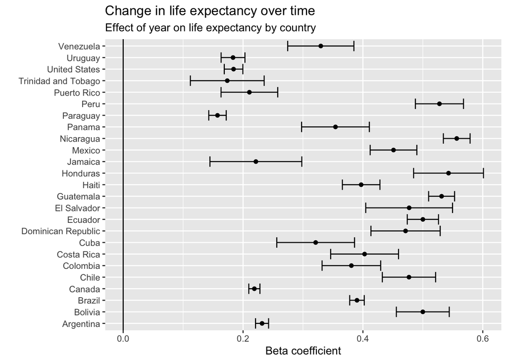

```r
# filter dataframe
mods %>%
  filter(
    continent == "Americas",
    term == "year"
    ) %>%
  # several elements of the plot will be used by multiple geoms
  # set those within the ggplot() call at the top to pass to each geom
  ggplot(aes(x = estimate, y = country)) +
  # plot the point estimate
  geom_point() +
  # plot the confidence intervals
  geom_errorbarh(aes(xmin = conf.low, xmax = conf.high)) +
  # add reference line at x=0
  geom_vline(aes(xintercept = 0)) +
  # NEW: add/edit title and axis labels
  labs(
    title = "Change in life expectancy over time",
    subtitle = "Effect of year on life expectancy by country"
  ) +
  xlab("Beta coefficient") +
  ylab("")
```

## Add color to plot

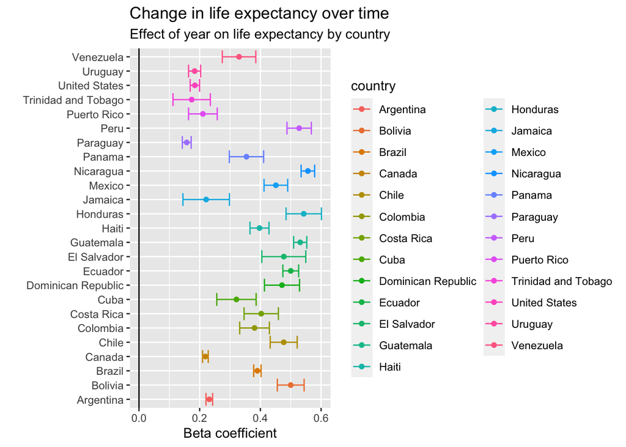

```r
# filter dataframe
mods %>%
  filter(
    continent == "Americas",
    term == "year"
    ) %>%
  # several elements of the plot will be used by multiple geoms
  # set those within the ggplot() call at the top to pass to each geom
  # NEW: set color to country
  ggplot(aes(x = estimate, y = country, color = country)) +
  # plot the point estimate
  geom_point() +
  # plot the confidence intervals
  geom_errorbarh(aes(xmin = conf.low, xmax = conf.high)) +
  # add reference line at x=0
  geom_vline(aes(xintercept = 0)) +
  # add/edit title and axis labels
  labs(
    title = "Change in life expectancy over time",
    subtitle = "Effect of year on life expectancy by country"
  ) +
  xlab("Beta coefficient") +
  ylab("")
```

Now we have this unnecessary legend. Remove from plot.

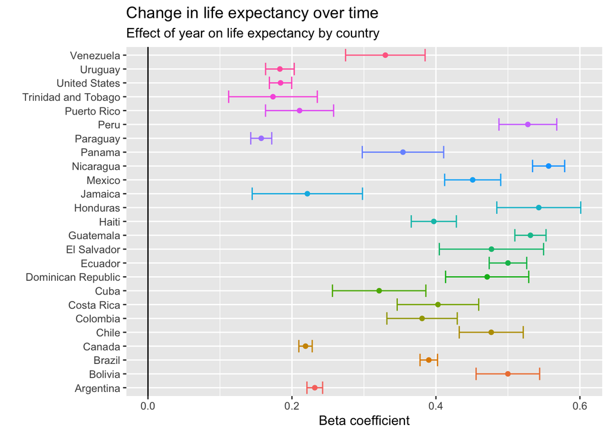

```r
# filter dataframe
mods %>%
  filter(
    continent == "Americas",
    term == "year"
    ) %>%
  # several elements of the plot will be used by multiple geoms
  # set those within the ggplot() call at the top to pass to each geom
  # set color to country
  ggplot(aes(x = estimate, y = country, color = country)) +
  # plot the point estimate
  geom_point() +
  # plot the confidence intervals
  geom_errorbarh(aes(xmin = conf.low, xmax = conf.high)) +
  # add reference line at x=0
  geom_vline(aes(xintercept = 0)) +
  # add/edit title and axis labels
  labs(
    title = "Change in life expectancy over time",
    subtitle = "Effect of year on life expectancy by country"
  ) +
  xlab("Beta coefficient") +
  ylab("") +
  # NEW: remove legend
  theme(legend.position = "none")
```

## Change plot theme

If you’re like me, you really dislike R’s default “gray” background. Luckily, ggplot comes with several different “themes” you can use.

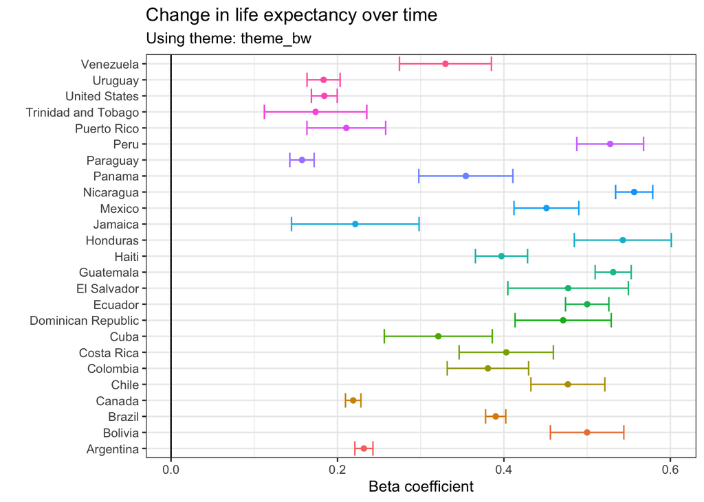

```r
# using theme_bw
# filter dataframe
mods %>%
  filter(
    continent == "Americas",
    term == "year"
    ) %>%
  # several elements of the plot will be used by multiple geoms
  # set those within the ggplot() call at the top to pass to each geom
  # set color to country
  ggplot(aes(x = estimate, y = country, color = country)) +
  # plot the point estimate
  geom_point() +
  # plot the confidence intervals
  geom_errorbarh(aes(xmin = conf.low, xmax = conf.high)) +
  # add reference line at x=0
  geom_vline(aes(xintercept = 0)) +
  # add/edit title and axis labels
  labs(
    title = "Change in life expectancy over time",
    subtitle = "Using theme: theme_bw"
  ) +
  xlab("Beta coefficient") +
  ylab("") +
  # NEW: set plot theme - must happen above any other changes to the theme
  theme_bw() +
  # remove legend
  theme(legend.position = "none")
```

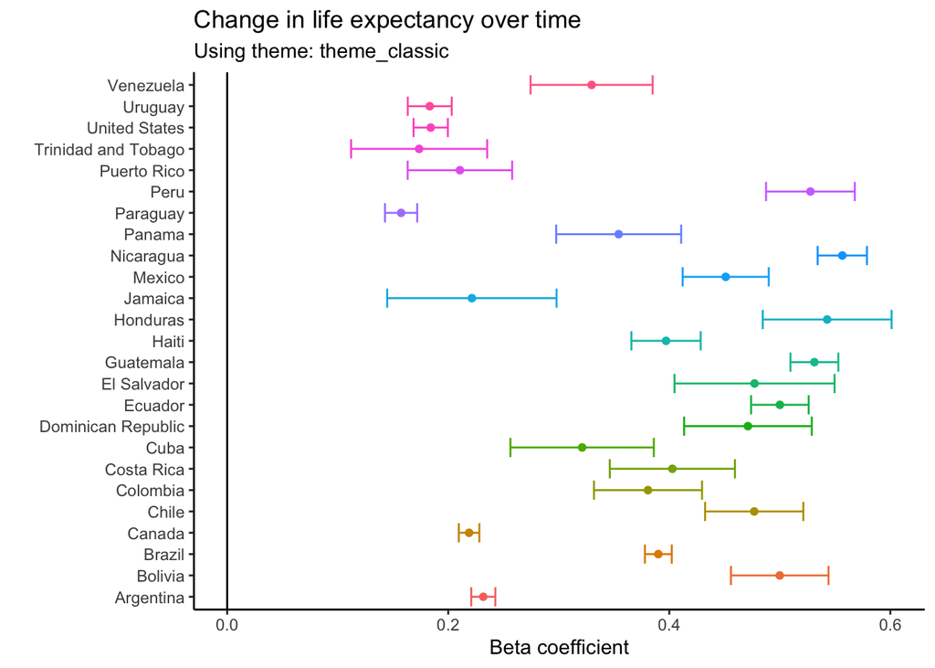

```r
# using theme_classic
# filter dataframe
mods %>%
  filter(
    continent == "Americas",
    term == "year"
    ) %>%
  # several elements of the plot will be used by multiple geoms
  # set those within the ggplot() call at the top to pass to each geom
  # set color to country
  ggplot(aes(x = estimate, y = country, color = country)) +
  # plot the point estimate
  geom_point() +
  # plot the confidence intervals
  geom_errorbarh(aes(xmin = conf.low, xmax = conf.high)) +
  # add reference line at x=0
  geom_vline(aes(xintercept = 0)) +
  # add/edit title and axis labels
  labs(
    title = "Change in life expectancy over time",
    subtitle = "Using theme: theme_classic"
  ) +
  xlab("Beta coefficient") +
  ylab("") +
  # NEW: set plot theme - must happen above any other changes to the theme
  theme_classic() +
  # remove legend
  theme(legend.position = "none")
```

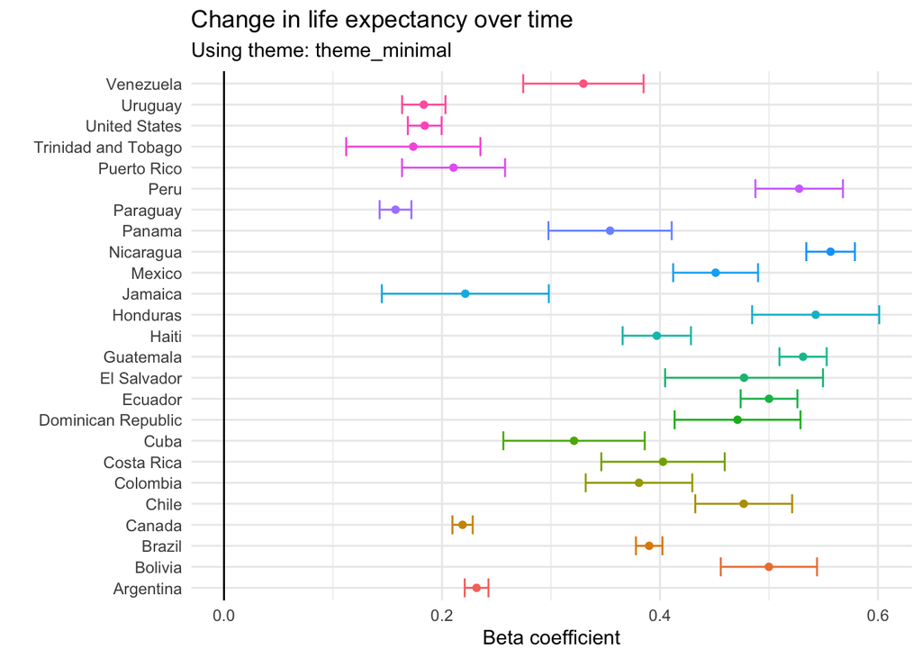

```r
# using theme_minimal
# filter dataframe
mods %>%
  filter(
    continent == "Americas",
    term == "year"
    ) %>%
  # several elements of the plot will be used by multiple geoms
  # set those within the ggplot() call at the top to pass to each geom
  # set color to country
  ggplot(aes(x = estimate, y = country, color = country)) +
  # plot the point estimate
  geom_point() +
  # plot the confidence intervals
  geom_errorbarh(aes(xmin = conf.low, xmax = conf.high)) +
  # add reference line at x=0
  geom_vline(aes(xintercept = 0)) +
  # add/edit title and axis labels
  labs(
    title = "Change in life expectancy over time",
    subtitle = "Using theme: theme_minimal"
  ) +
  xlab("Beta coefficient") +
  ylab("") +
  # NEW: set plot theme - must happen above any other changes to the theme
  theme_minimal() +
  # remove legend
  theme(legend.position = "none")
```

I personally want a combination of theme_classic and theme_minimal (dark, solid x and y axis with light gridlines). I also want to change the look of the reference line so it is dashed and not as dark. I will manually make those adjustments.

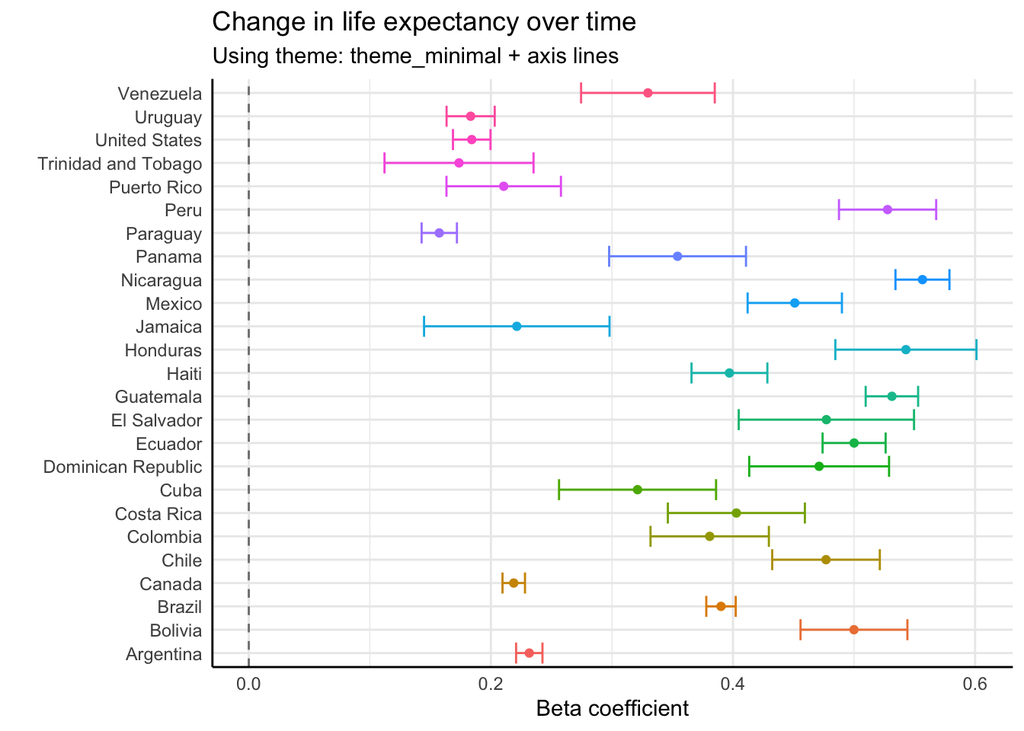

```r
# using theme_minimal
# filter dataframe
mods %>%
  filter(
    continent == "Americas",
    term == "year"
    ) %>%
  # several elements of the plot will be used by multiple geoms
  # set those within the ggplot() call at the top to pass to each geom
  # set color to country
  ggplot(aes(x = estimate, y = country, color = country)) +
  # plot the point estimate
  geom_point() +
  # plot the confidence intervals
  geom_errorbarh(aes(xmin = conf.low, xmax = conf.high)) +
  # add reference line at x=0 NEW: make gray and dashed
  geom_vline(aes(xintercept = 0), color = "grey50", lty = "dashed") +
  # add/edit title and axis labels
  labs(
    title = "Change in life expectancy over time",
    subtitle = "Using theme: theme_minimal + axis lines"
  ) +
  xlab("Beta coefficient") +
  ylab("") +
  # set plot theme - must happen above any other changes to the theme
  theme_minimal() +
  # remove legend
  theme(
    legend.position = "none",
    # NEW: add back axis lines
    axis.line = element_line()
    )
```

## Re-order y-axis by coefficient magnitude

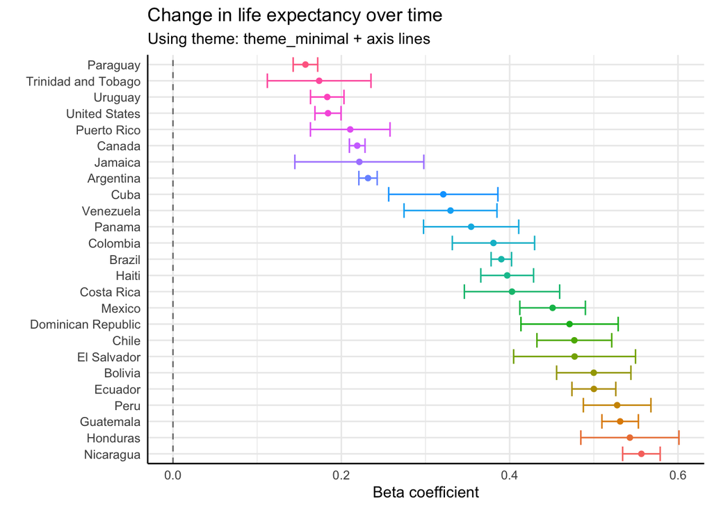

```r
# NEW: get rank order
country_rnk <- mods %>%
  filter(
    continent == "Americas",
    term == "year"
    ) %>%
  arrange(desc(estimate)) %>%
  pull(country)


# using theme_minimal
# filter dataframe
mods %>%
  filter(
    continent == "Americas",
    term == "year"
    ) %>%
  # NEW: make country a factor ordered by estimate magnitude
  mutate(country = factor(country, levels = country_rnk)) %>%
  # several elements of the plot will be used by multiple geoms
  # set those within the ggplot() call at the top to pass to each geom
  # set color to country
  ggplot(aes(x = estimate, y = country, color = country)) +
  # plot the point estimate
  geom_point() +
  # plot the confidence intervals
  geom_errorbarh(aes(xmin = conf.low, xmax = conf.high)) +
  # add reference line at x=0 NEW: make gray and dashed
  geom_vline(aes(xintercept = 0), color = "grey50", lty = "dashed") +
  # add/edit title and axis labels
  labs(
    title = "Change in life expectancy over time",
    subtitle = "Using theme: theme_minimal + axis lines"
  ) +
  xlab("Beta coefficient") +
  ylab("") +
  # set plot theme - must happen above any other changes to the theme
  theme_minimal() +
  # remove legend
  theme(
    legend.position = "none",
    # NEW: add back axis lines
    axis.line = element_line()
    )
```

Now that the points are in rank order, we could change the color palette to match the sequential nature of the data. I am a fan of the [viridis](https://cran.r-project.org/web/packages/viridis/vignettes/intro-to-viridis.html) color palettes. They are designed to be color-blind friendly and perceptually uniform, and they are, in my opinion, quite pretty. They’re also conveniently built into ggplot2.

## Manually change the color palette

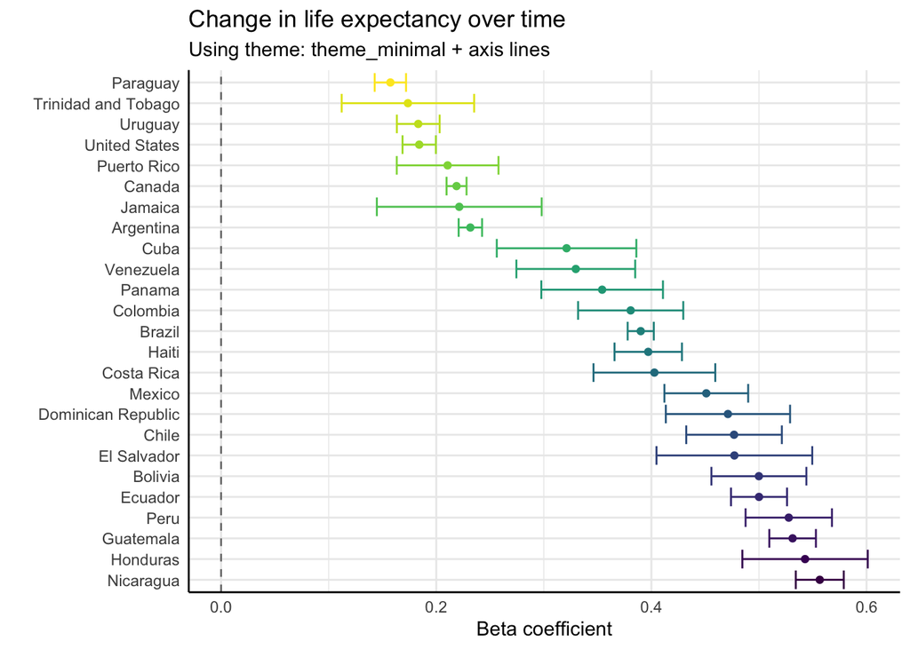

```r
# filter dataframe
mods %>%
  filter(
    continent == "Americas",
    term == "year"
    ) %>%
  # NEW: make country a factor ordered by estimate magnitude
  mutate(country = factor(country, levels = country_rnk)) %>%
  # several elements of the plot will be used by multiple geoms
  # set those within the ggplot() call at the top to pass to each geom
  # set color to country
  ggplot(aes(x = estimate, y = country, color = country)) +
  # plot the point estimate
  geom_point() +
  # plot the confidence intervals
  geom_errorbarh(aes(xmin = conf.low, xmax = conf.high)) +
  # add reference line at x=0 NEW: make gray and dashed
  geom_vline(aes(xintercept = 0), color = "grey50", lty = "dashed") +
  # NEW: set color palette
  scale_color_viridis_d() +
  # add/edit title and axis labels
  labs(
    title = "Change in life expectancy over time",
    subtitle = "Using theme: theme_minimal + axis lines"
  ) +
  xlab("Beta coefficient") +
  ylab("") +
  # set plot theme - must happen above any other changes to the theme
  theme_minimal() +
  # remove legend
  theme(
    legend.position = "none",
    # NEW: add back axis lines
    axis.line = element_line()
    )
```